# AMC Mobile Individual Assignment

Shen YANG

11/13/2018

## Data Processing

```r
rm(list=ls())
setwd("~/Documents/UCI/Customer and Social Analytics/Mobile Analytics Individual Assignment")

library(dplyr)
# read data
geo_data = read.csv("Geo-Fence Analytics.csv")

# create imp_large
geo_data = mutate(geo_data, imp_large = ifelse(imp_size == "728x90",1,0))
geo_data$imp_large = as.factor(geo_data$imp_large)

# create cat_entertainment
geo_data = mutate(geo_data, cat_entertainment = ifelse(app_topcat %in% c("IAB1","IAB1-6"),1,0))
geo_data$cat_entertainment = as.factor(geo_data$cat_entertainment)

# create cat_social
geo_data = mutate(geo_data, cat_social = ifelse(app_topcat == "IAB14",1,0))
geo_data$cat_social = as.factor(geo_data$cat_social)

# create cat_tech
geo_data = mutate(geo_data, cat_tech = ifelse(app_topcat == "IAB19-6",1,0))
geo_data$cat_tech = as.factor(geo_data$cat_tech)

# create os_ios
geo_data = mutate(geo_data, os_ios = ifelse(device_os == "iOS",1,0))
geo_data$os_ios = as.factor(geo_data$os_ios)

# create distance
library(aspace)
geo_data = mutate(geo_data, distance = 6371 * acos(cos(as_radians(device_lat)) *
                    cos(as_radians(geofence_lat)) * cos(as_radians(device_lon) - as_radians(geofence_lon))
                    + sin(as_radians(device_lat)) * sin(as_radians(geofence_lat))) )

# create distance_squared
geo_data = mutate(geo_data, distance_squared = distance^2)

# create ln_app_review_vol
geo_data = mutate(geo_data, ln_app_review_vol = log(app_review_vol))

head(geo_data)
```

```
##   imp_size app_id                                          app_name
## 1   320x50     62 Dictionary.com Android APP - First look inventory
## 2   320x50     62 Dictionary.com Android APP - First look inventory
## 3   320x50     62 Dictionary.com Android APP - First look inventory
## 4   320x50     62 Dictionary.com Android APP - First look inventory
## 5   320x50     62 Dictionary.com Android APP - First look inventory
## 6   320x50     62 Dictionary.com Android APP - First look inventory
##   app_pub app_topcat app_review_vol app_review_val device_lat device_lon
## 1               IAB5          63228            4.6   33.84575  -117.8250
## 2               IAB5          63228            4.6   33.85843  -117.8605
## 3               IAB5          63228            4.6   33.77808  -117.8752
## 4               IAB5          63228            4.6   33.87387  -117.8174
## 5               IAB5          63228            4.6   33.94048  -117.9675
## 6               IAB5          63228            4.6   33.80514  -118.0167
##   device_zip device_os geofence_lat geofence_lon gepfence_radius didclick
```

[output cut: 20 more lines]

## Descriptive Statistics

### Summary Statistics

```r
# summary statistics
library(pastecs)
col_name = c("didclick","distance","imp_large","cat_entertainment", "cat_social", "cat_tech",
             "os_ios", "ln_app_review_vol" , "app_review_val")
for(i in 1:length(col_name)){

  if(col_name[i] %in% c("imp_large","cat_entertainment", "cat_social", "cat_tech",
                        "os_ios")){
    print(col_name[i])
    print(summary(geo_data[,which(colnames(geo_data)==col_name[i])]))
  }else{
    print(col_name[i])
    print(stat.desc(geo_data[,which(colnames(geo_data)==col_name[i])]))
  }

}
```

```
## [1] "didclick"
##      nbr.val     nbr.null       nbr.na          min          max
## 1.215670e+05 1.207390e+05 0.000000e+00 0.000000e+00 1.000000e+00
##        range          sum       median         mean      SE.mean
## 1.000000e+00 8.280000e+02 0.000000e+00 6.811059e-03 2.358942e-04
## CI.mean.0.95          var      std.dev     coef.var
## 4.623487e-04 6.764724e-03 8.224794e-02 1.207565e+01
## [1] "distance"
##      nbr.val     nbr.null       nbr.na          min          max
## 1.215670e+05 0.000000e+00 0.000000e+00 2.075894e-02 1.178666e+01
##        range          sum       median         mean      SE.mean
## 1.176590e+01 3.627240e+05 2.020864e+00 2.983737e+00 7.596201e-03
## CI.mean.0.95          var      std.dev     coef.var
## 1.488843e-02 7.014691e+00 2.648526e+00 8.876540e-01
## [1] "imp_large"
##     0     1
## 93500 28067
## [1] "cat_entertainment"
##     0     1
## 87051 34516
## [1] "cat_social"
##      0      1
## 106356  15211
## [1] "cat_tech"
##     0     1
## 58614 62953
## [1] "os_ios"
##     0     1
## 91131 30436
## [1] "ln_app_review_vol"
##      nbr.val     nbr.null       nbr.na          min          max
## 1.215670e+05 0.000000e+00 0.000000e+00 7.080868e+00 1.293770e+01
##        range          sum       median         mean      SE.mean
## 5.856834e+00 1.222575e+06 1.008722e+01 1.005680e+01 1.826862e-03
## CI.mean.0.95          var      std.dev     coef.var
## 3.580618e-03 4.057205e-01 6.369619e-01 6.333645e-02
## [1] "app_review_val"
##      nbr.val     nbr.null       nbr.na          min          max
## 1.215670e+05 0.000000e+00 0.000000e+00 1.400000e+00 4.700000e+00
##        range          sum       median         mean      SE.mean
## 3.300000e+00 4.443119e+05 3.400000e+00 3.654873e+00 1.034841e-03
## CI.mean.0.95          var      std.dev     coef.var
## 2.028272e-03 1.301857e-01 3.608125e-01 9.872095e-02
```

### The Correlations Among The Above Variables

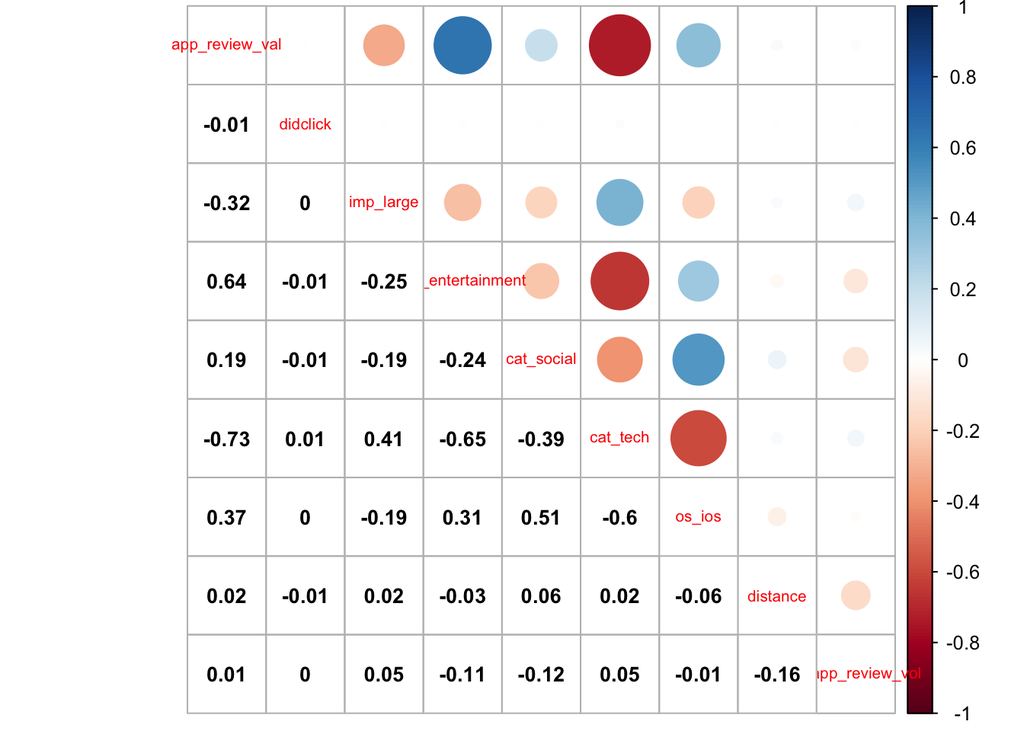

```r
# the correlations among the above variables
library(corrplot)
data.matrix(geo_data[,which(colnames(geo_data) %in% col_name)]) %>%
  cor() %>%
  corrplot.mixed(lower.col = "black", number.cex = .85, tl.cex = 0.65)
```

### The Relationship Of Distance (X-Axis) And Click-Through-Rate (Y-Axis)

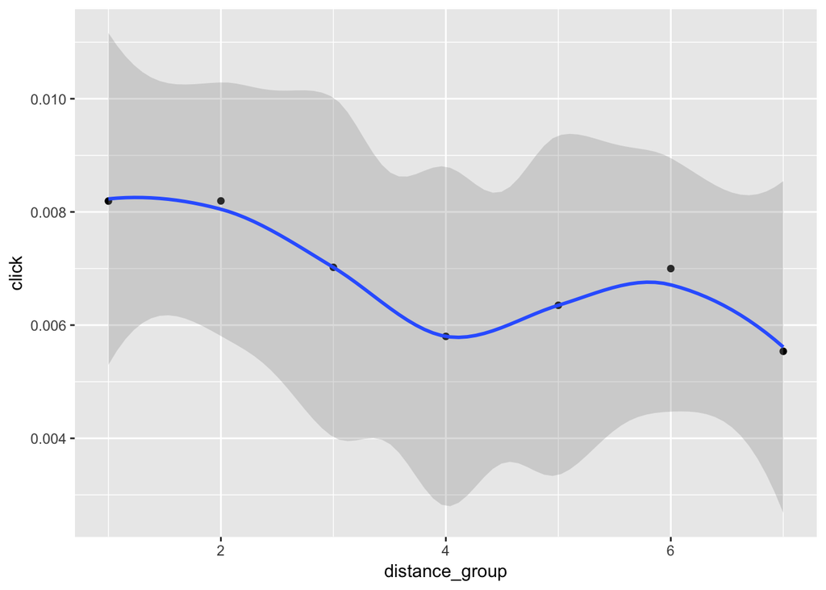

```r
# the relationship of distance (x-axis) and click-through-rate (y-axis)
library(ggplot2)
# create distance_group
geo_data$distance_group[geo_data$distance > 10] = 7
geo_data$distance_group[geo_data$distance <= 10] = 6
geo_data$distance_group[geo_data$distance <= 7] = 5
geo_data$distance_group[geo_data$distance <= 4] = 4
geo_data$distance_group[geo_data$distance <= 2] = 3
geo_data$distance_group[geo_data$distance <= 1] = 2
geo_data$distance_group[geo_data$distance <= 0.5] = 1
geo_data$distance_group = as.factor(geo_data$distance_group)

# calculate the click_through_rate
click_through_rate = c()
for (i in 1:7) {
  click_through_rate[i] = sum(geo_data$didclick[which(geo_data$distance_group==i)])/
    length(which(geo_data$distance_group==i))
}
distance_click = data.frame(distance_group = c(1:7), click = click_through_rate)

# plot click_through_rate ~ distance_group
ggplot(data = distance_click, aes(distance_group, click)) +
  geom_point() +
  geom_smooth(alpha=0.3, se=T) +
  xlab("distance_group")
```

### Explore Click_through_rate ~ Device

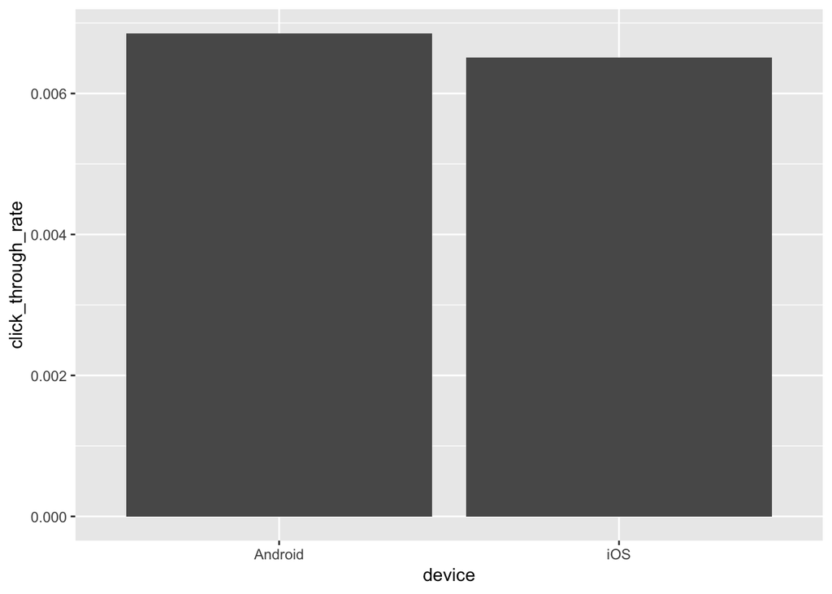

```r
# explore click_through_rate ~ device
click_through_rate2 = c()
click_through_rate2[1] = sum(geo_data$didclick[which(geo_data$device_os=="Android")])/
  length(which(geo_data$device_os=="Android"))
click_through_rate2[2] = sum(geo_data$didclick[which(geo_data$device_os=="iOS")])/
  length(which(geo_data$device_os=="iOS"))

device_click = data.frame(device = c("Android","iOS"), click = click_through_rate2)

ggplot(data = device_click, aes(device, click)) +
  geom_col() +
  ylab("click_through_rate")
```

## Logistics Regression

### Use whole data set

```r
#put all varibles into the regression
geo_data$didclick = as.factor(geo_data$didclick)
fit1 = glm(didclick ~ distance + distance_squared + imp_large + cat_entertainment + cat_social +
           cat_tech + os_ios + ln_app_review_vol + app_review_val, data = geo_data, family = "binomial")
summary(fit1)
```

```
##
## Call:
## glm(formula = didclick ~ distance + distance_squared + imp_large +
##     cat_entertainment + cat_social + cat_tech + os_ios + ln_app_review_vol +
##     app_review_val, family = "binomial", data = geo_data)
##
## Deviance Residuals:
##     Min       1Q   Median       3Q      Max
## -0.1510  -0.1272  -0.1148  -0.1042   3.4025
##
## Coefficients:
##                     Estimate Std. Error z value Pr(>|z|)
## (Intercept)        -6.616818   0.896958  -7.377 1.62e-13 ***
## distance           -0.117927   0.045073  -2.616 0.008888 **
## distance_squared    0.009166   0.004362   2.102 0.035583 *
## imp_large1         -0.352164   0.091782  -3.837 0.000125 ***
## cat_entertainment1 -0.096143   0.178941  -0.537 0.591069
## cat_social1        -0.226695   0.211394  -1.072 0.283550
## cat_tech1           0.687657   0.176312   3.900 9.61e-05 ***
## os_ios1             0.385895   0.126361   3.054 0.002259 **
## ln_app_review_vol   0.030512   0.063037   0.484 0.628368
## app_review_val      0.323831   0.186656   1.735 0.082757 .
## ---
## Signif. codes:  0 '***' 0.001 '**' 0.01 '*' 0.05 '.' 0.1 ' ' 1
##
## (Dispersion parameter for binomial family taken to be 1)
##
##     Null deviance: 9912.5  on 121566  degrees of freedom
## Residual deviance: 9857.1  on 121557  degrees of freedom
## AIC: 9877.1
##
## Number of Fisher Scoring iterations: 8
```

```r
# simplify the model

#Variable Importance
#To assess the relative importance of individual predictors in the model, we can also look at
# the absolute value of the t-statistic for each model parameter.
library(caret)
varImp(fit1)
```

```
##                      Overall
## distance           2.6163380
## distance_squared   2.1016582
## imp_large1         3.8369736
## cat_entertainment1 0.5372882
## cat_social1        1.0723789
## cat_tech1          3.9002275
## os_ios1            3.0539063
## ln_app_review_vol  0.4840253
## app_review_val     1.7349093
```

```r
#Delete non-significant varibles
fit2 = glm(didclick ~ distance + distance_squared + imp_large +
             cat_tech + os_ios, data = geo_data, family = "binomial")
summary(fit2)
```

```
##
## Call:
## glm(formula = didclick ~ distance + distance_squared + imp_large +
##     cat_tech + os_ios, family = "binomial", data = geo_data)
##
## Deviance Residuals:
##     Min       1Q   Median       3Q      Max
## -0.1471  -0.1254  -0.1152  -0.1045   3.3277
##
## Coefficients:
##                   Estimate Std. Error z value Pr(>|z|)
## (Intercept)      -5.091004   0.110148 -46.220  < 2e-16 ***
## distance         -0.119992   0.045032  -2.665 0.007708 **
## distance_squared  0.009158   0.004364   2.099 0.035858 *
## imp_large1       -0.346716   0.091717  -3.780 0.000157 ***
## cat_tech1         0.574871   0.100695   5.709 1.14e-08 ***
## os_ios1           0.292210   0.111257   2.626 0.008628 **
## ---
## Signif. codes:  0 '***' 0.001 '**' 0.01 '*' 0.05 '.' 0.1 ' ' 1
##
## (Dispersion parameter for binomial family taken to be 1)
##
##     Null deviance: 9912.5  on 121566  degrees of freedom
## Residual deviance: 9862.8  on 121561  degrees of freedom
## AIC: 9874.8
##
## Number of Fisher Scoring iterations: 8
```

```r
#Model comparison -> fit2 is better
anova(fit1, fit2, test="Chisq")
```

```
## Analysis of Deviance Table
##
## Model 1: didclick ~ distance + distance_squared + imp_large + cat_entertainment +
##     cat_social + cat_tech + os_ios + ln_app_review_vol + app_review_val
## Model 2: didclick ~ distance + distance_squared + imp_large + cat_tech +
##     os_ios
##   Resid. Df Resid. Dev Df Deviance Pr(>Chi)
## 1    121557     9857.1
## 2    121561     9862.8 -4  -5.7494   0.2187
```

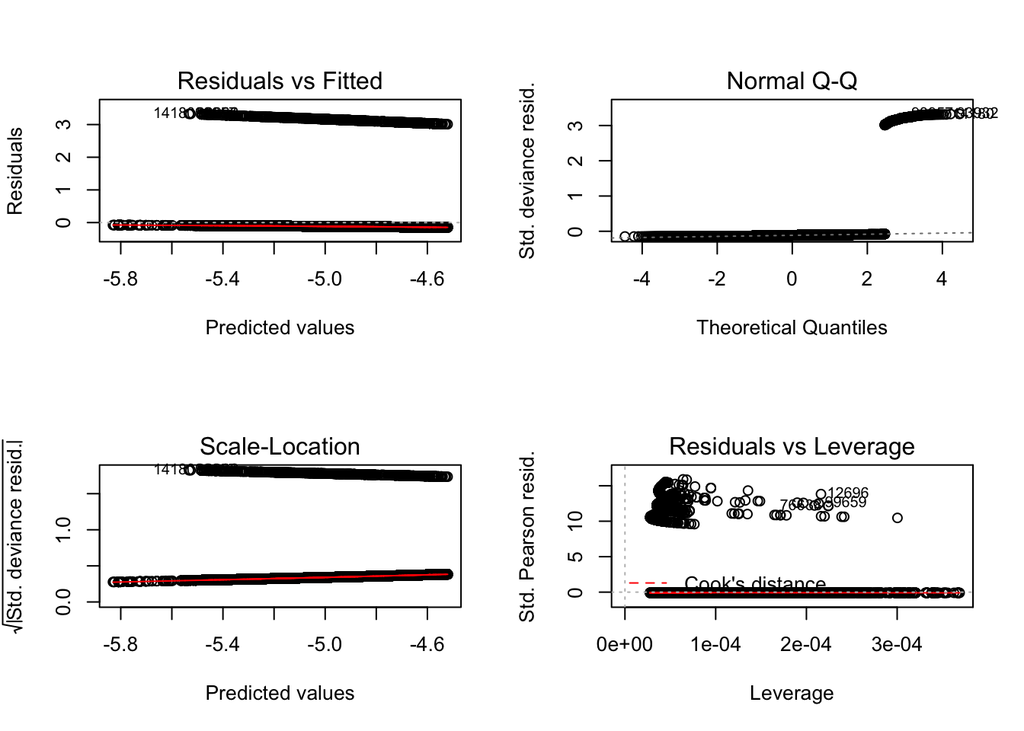

```r
#Model Diagnosis
par(mfrow=c(2,2))
plot(fit2)
```

```r
par(mfrow=c(1,1))

#Identify the outliers
length(which(abs(resid(fit2))>3))
```

```
## [1] 828
```

```r
summary(geo_data$didclick[which(abs(resid(fit2))>3)])
```

```
##   0   1
##   0 828
```

### Try to use choice-based sample

We can see that all the observations which didclick = 1 have extrem large standard residual(higher than 3). I suppose that the reason is the sample of didclick = 0 (120739) is far more than the sample of didclick = 1 (828). In the next part, I try to use a choice-based sample to see whether we can improve the model. The choice-based sample consist of all the observations with didclick = 1, 828 in total, and 828 random selected observations. The sample size of choice-based sample is 828+828 = 1656.

```r
#Generate a choice-based sample
geo_data_choice_based = filter(geo_data, didclick == 1)
a = filter(geo_data, didclick == 0)
set.seed(442)
geo_data_choice_based = rbind(geo_data_choice_based, a[sample(dim(a)[1],828),])
rm(a)

#put all varibles into the regression at first
fit1_choice_based = glm(didclick ~ distance + distance_squared + imp_large + cat_entertainment + cat_social +
                          cat_tech + os_ios + ln_app_review_vol + app_review_val, data = geo_data_choice_based,
                        family = "binomial")
summary(fit1_choice_based)
```

```
##
## Call:
## glm(formula = didclick ~ distance + distance_squared + imp_large +
##     cat_entertainment + cat_social + cat_tech + os_ios + ln_app_review_vol +
##     app_review_val, family = "binomial", data = geo_data_choice_based)
##
## Deviance Residuals:
##      Min        1Q    Median        3Q       Max
## -1.46960  -1.13178   0.09836   1.15860   1.60540
##
## Coefficients:
##                    Estimate Std. Error z value Pr(>|z|)
## (Intercept)        -1.21070    1.12698  -1.074  0.28269
## distance           -0.18408    0.06422  -2.866  0.00415 **
## distance_squared    0.01556    0.00637   2.442  0.01460 *
## imp_large1         -0.54225    0.13203  -4.107 4.01e-05 ***
## cat_entertainment1 -0.12286    0.25602  -0.480  0.63132
## cat_social1        -0.23121    0.28128  -0.822  0.41109
## cat_tech1           0.72844    0.22241   3.275  0.00106 **
## os_ios1             0.25876    0.16848   1.536  0.12457
## ln_app_review_vol   0.05679    0.09173   0.619  0.53585
## app_review_val      0.18188    0.23602   0.771  0.44095
## ---
## Signif. codes:  0 '***' 0.001 '**' 0.01 '*' 0.05 '.' 0.1 ' ' 1
##
## (Dispersion parameter for binomial family taken to be 1)
##
##     Null deviance: 2295.7  on 1655  degrees of freedom
## Residual deviance: 2243.4  on 1646  degrees of freedom
## AIC: 2263.4
##
## Number of Fisher Scoring iterations: 4
```

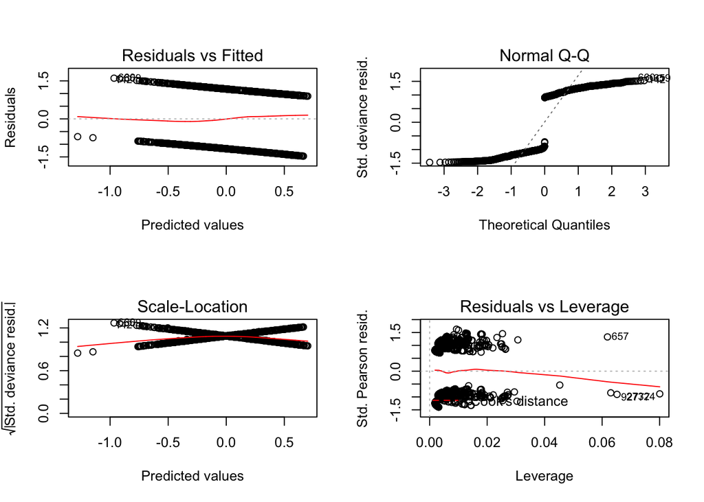

```r
par(mfrow=c(2,2))
plot(fit1_choice_based)
```

```r
par(mfrow=c(1,1))
```

#### Liner Assumption

The result of residual plots shows that the model is still not good. So I decided to examine the liner relationship between the log(p/(1-p)) and each predictor variables. The plots give evidence that the model against the liner assumption, so the model fit could be bad.

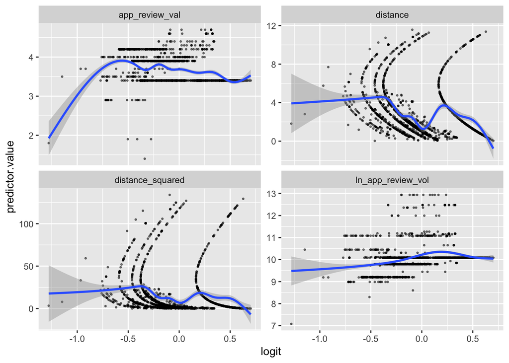

```r
#create a dataset for plot
testdata = transmute(geo_data_choice_based, distance, distance_squared, ln_app_review_vol, app_review_val)
predictors = colnames(testdata)
library(tidyr)
prob = predict(fit1_choice_based,type = "response")
testdata = testdata %>%
  mutate(logit = log(prob/(1-prob))) %>%
  gather(key = "predictors", value = "predictor.value", -logit)

#Create the scatter plots:
ggplot(testdata, aes(logit, predictor.value)) +
  geom_point(size = 0.5, alpha = 0.5) +
  geom_smooth() +
  facet_wrap(~predictors, scales = "free_y")
```

#### Model Improvement

Still something can be done to slightly improve the model.

```r
#Multicollinearity -> Either distance or distance^2 should be delete. Function varImp shows that distance is more important
library(car)
vif(fit1_choice_based)
```

```
##          distance  distance_squared         imp_large cat_entertainment
##         11.202986         11.118133          1.236223          5.237269
##        cat_social          cat_tech            os_ios ln_app_review_vol
##          3.377614          4.931225          2.191944          1.228339
##    app_review_val
##          2.956486
```

```r
varImp(fit1_choice_based)
```

```
##                      Overall
## distance           2.8662611
## distance_squared   2.4422651
## imp_large1         4.1069759
## cat_entertainment1 0.4798758
## cat_social1        0.8219845
## cat_tech1          3.2751739
## os_ios1            1.5358753
## ln_app_review_vol  0.6190984
## app_review_val     0.7705962
```

```r
#Delete unimportant varibles
fit2_choice_based = glm(didclick ~ distance + imp_large + cat_entertainment + cat_tech,
                        data = geo_data_choice_based,
                        family = "binomial")
summary(fit2_choice_based)
```

```
##
## Call:
## glm(formula = didclick ~ distance + imp_large + cat_entertainment +
##     cat_tech, family = "binomial", data = geo_data_choice_based)
##
## Deviance Residuals:
##      Min        1Q    Median        3Q       Max
## -1.40423  -1.12188   0.04734   1.21095   1.58318
##
## Coefficients:
##                    Estimate Std. Error z value Pr(>|z|)
## (Intercept)        -0.13646    0.12996  -1.050   0.2937
## distance           -0.04074    0.01927  -2.114   0.0345 *
## imp_large1         -0.52991    0.13134  -4.035 5.47e-05 ***
## cat_entertainment1  0.06287    0.14941   0.421   0.6739
## cat_tech1           0.66541    0.14274   4.662 3.13e-06 ***
## ---
## Signif. codes:  0 '***' 0.001 '**' 0.01 '*' 0.05 '.' 0.1 ' ' 1
##
## (Dispersion parameter for binomial family taken to be 1)
##
##     Null deviance: 2295.7  on 1655  degrees of freedom
## Residual deviance: 2254.4  on 1651  degrees of freedom
## AIC: 2264.4
##
## Number of Fisher Scoring iterations: 4
```

```r
#Delete cat_entertainment since it is nolonger significant in model fit2_choice_based
fit3_choice_based = glm(didclick ~ distance + imp_large + cat_tech,
                        data = geo_data_choice_based,
                        family = "binomial")
summary(fit3_choice_based)
```

```
##
## Call:
## glm(formula = didclick ~ distance + imp_large + cat_tech, family = "binomial",
##     data = geo_data_choice_based)
##
## Deviance Residuals:
##      Min        1Q    Median        3Q       Max
## -1.40462  -1.11882   0.05067   1.21038   1.59515
##
## Coefficients:
##             Estimate Std. Error z value Pr(>|z|)
## (Intercept) -0.09743    0.09089  -1.072   0.2838
## distance    -0.04136    0.01921  -2.153   0.0313 *
## imp_large1  -0.52780    0.13128  -4.020 5.81e-05 ***
## cat_tech1    0.62741    0.11042   5.682 1.33e-08 ***
## ---
## Signif. codes:  0 '***' 0.001 '**' 0.01 '*' 0.05 '.' 0.1 ' ' 1
##
## (Dispersion parameter for binomial family taken to be 1)
##
##     Null deviance: 2295.7  on 1655  degrees of freedom
## Residual deviance: 2254.6  on 1652  degrees of freedom
## AIC: 2262.6
##
## Number of Fisher Scoring iterations: 4
```

```r
#Model comparison -> fit3_choice_based is better
anova(fit3_choice_based, fit1_choice_based, test="Chisq")
```

```
## Analysis of Deviance Table
##
## Model 1: didclick ~ distance + imp_large + cat_tech
## Model 2: didclick ~ distance + distance_squared + imp_large + cat_entertainment +
##     cat_social + cat_tech + os_ios + ln_app_review_vol + app_review_val
##   Resid. Df Resid. Dev Df Deviance Pr(>Chi)
## 1      1652     2254.6
## 2      1646     2243.4  6    11.14  0.08415 .
## ---
## Signif. codes:  0 '***' 0.001 '**' 0.01 '*' 0.05 '.' 0.1 ' ' 1
```

```r
anova(fit3_choice_based, fit2_choice_based, test="Chisq")
```

```
## Analysis of Deviance Table
##
## Model 1: didclick ~ distance + imp_large + cat_tech
## Model 2: didclick ~ distance + imp_large + cat_entertainment + cat_tech
##   Resid. Df Resid. Dev Df Deviance Pr(>Chi)
## 1      1652     2254.6
## 2      1651     2254.4  1  0.17714   0.6738
```

```r
#Since a choice-based sample is used, offset should be considered
populateRate = length(which(geo_data$didclick==1))/length(geo_data$didclick)
clickRate = 0.5

geo_data_choice_based$offsetvalue = log(((1 - populateRate)/populateRate)/((1 - clickRate)/clickRate))

#Model with offset
fit4_choice_based = glm(didclick ~ distance + imp_large + cat_tech,
                        data = geo_data_choice_based,
                        family = "binomial", offset = offsetvalue)
summary(fit4_choice_based)
```

```
##
## Call:
## glm(formula = didclick ~ distance + imp_large + cat_tech, family = "binomial",
##     data = geo_data_choice_based, offset = offsetvalue)
##
## Deviance Residuals:
##      Min        1Q    Median        3Q       Max
## -1.40462  -1.11882   0.05067   1.21038   1.59515
##
## Coefficients:
##             Estimate Std. Error z value Pr(>|z|)
## (Intercept) -5.07980    0.09089 -55.888  < 2e-16 ***
## distance    -0.04136    0.01921  -2.153   0.0313 *
## imp_large1  -0.52780    0.13128  -4.020 5.81e-05 ***
## cat_tech1    0.62741    0.11042   5.682 1.33e-08 ***
## ---
## Signif. codes:  0 '***' 0.001 '**' 0.01 '*' 0.05 '.' 0.1 ' ' 1
##
## (Dispersion parameter for binomial family taken to be 1)
##
##     Null deviance: 2295.7  on 1655  degrees of freedom
## Residual deviance: 2254.6  on 1652  degrees of freedom
## AIC: 2262.6
##
## Number of Fisher Scoring iterations: 4
```

```r
#Compare the model result of whole data set and choice-based sample
#Use 'McFadden'. The measure ranges from 0 to just under 1, with values closer to zero indicating that the model has no predictive power.
#detailed can be find in: https://www.r-bloggers.com/evaluating-logistic-regression-models/
library(pscl)
pR2(fit2)
```

```
##           llh       llhNull            G2      McFadden          r2ML
## -4.931406e+03 -4.956238e+03  4.966391e+01  5.010243e-03  4.084478e-04
##          r2CU
##  5.216219e-03
```

```r
pR2(fit4_choice_based)
```

```
##           llh       llhNull            G2      McFadden          r2ML
## -1.127277e+03 -1.147852e+03  4.114973e+01  1.792467e-02  2.454268e-02
##          r2CU
##  3.272357e-02
```

#### Model Evaluation

Using ROC cureve and confusion matrix. The AUC = 0.594 and Accuracy = 0.5815, which are not very good.

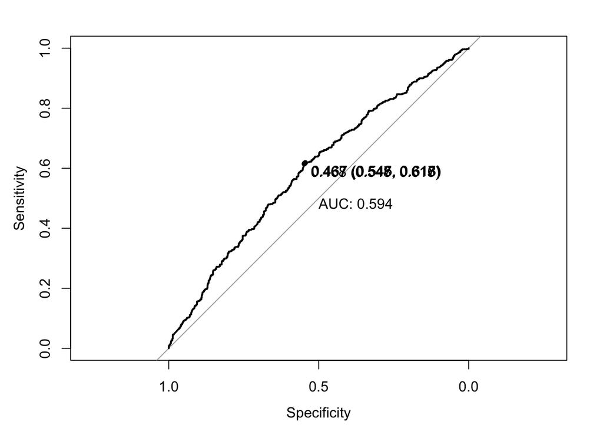

```r
#plot ROC curve
library(pROC)
g = roc(geo_data_choice_based$didclick ~ predict(fit4_choice_based,type = "response"))
plot(g,print.thres = "best",print.auc=TRUE)
```

```r
#find the best threshold
best_thres = coords(g, "best", ret=c("threshold", "specificity", "sensitivity"))
print(best_thres)
```

```
##                  best      best      best      best
## threshold   0.4673322 0.4673827 0.4674461 0.4675313
## specificity 0.5446860 0.5458937 0.5471014 0.5483092
## sensitivity 0.6183575 0.6171498 0.6159420 0.6147343
```

```r
#confusion matrix
as.numeric(predict(fit4_choice_based, newdata=geo_data_choice_based, type = "response") > best_thres[1]) %>%
  confusionMatrix(reference = geo_data_choice_based$didclick)
```

```
## Confusion Matrix and Statistics
##
##           Reference
## Prediction   0   1
##          0 451 316
##          1 377 512
##
##                Accuracy : 0.5815
##                  95% CI : (0.5573, 0.6054)
##     No Information Rate : 0.5
##     P-Value [Acc > NIR] : 1.74e-11
##
##                   Kappa : 0.163
##  Mcnemar's Test P-Value : 0.02265
##
##             Sensitivity : 0.5447
##             Specificity : 0.6184
##          Pos Pred Value : 0.5880
##          Neg Pred Value : 0.5759
##              Prevalence : 0.5000
##          Detection Rate : 0.2723
##    Detection Prevalence : 0.4632
##       Balanced Accuracy : 0.5815
##
##        'Positive' Class : 0
##
```

#### Coefficient Interpretation

Generally, large impression size has a very negative effect on the click. Distance has a mild negative effect on the click while if the app_topcat equal to “IAB19-6”, it will have a significant positive effect on the click. From the quantitative perspective, for example, if the app_topcat equal to “IAB19-6”, the odds of click (p/(1-p)) will increase to around 1.87 time compared to app_topcat equal to others.

```r
exp(coef(fit4_choice_based))
```

```
## (Intercept)    distance  imp_large1   cat_tech1
## 0.006221163 0.959482879 0.589901132 1.872749279
```